# MH3511 Tut 5 Notes

Caleb Tay (caleb.tay@ntu.edu.sg)

20 Feb 2026

# Some properties of the normal distribution

The normal distribution is parameterised by two things: the distribution’s **mean** and **variance**. Commonly we denote them with $\mu$ and $\sigma^2$.

Say we have a random variable that follows the normal distribution, say $X \sim N(\mu, \sigma^2)$. This variable has mean $\mu$ and variance $\sigma^2$, or equivalently, standard deviation $\sigma$.

We can shift the mean left or right (negatively or positively) by adding or subtracting a fixed constant to $X$. Consider $(X+c)$, which will have mean $\mu + c$. The variance remains unchanged.

The variance can be changed by multiplying a fixed constant to $X$. $(cX)$ will have variance $c^2\sigma^2$. The mean is also scaled accordingly to $c\mu$.

So, to transform this variable $X \sim N(\mu, \sigma^2)$ into the standard normal distribution $Z \sim N(0, 1)$, we have to subtract the mean $\mu$ and divide by $\sigma$.

$$X \sim N(\mu, \sigma^2) \iff (X - \mu)
\sim N(0, \sigma^2) \iff \frac{X-\mu}{\sigma} \sim N(0, 1)$$

This actually corresponds with the properties of expectation and variance, i.e. $E(aX+b) = aE(X) + b$ and $Var(aX+b) = a^2Var(X)$.

# Confidence intervals

Confidence intervals are expressed with some value between 0 and 1. In the context of estimating the sample mean, for example, a 0.9-confidence interval means that if we repeatedly construct 0.9-confidence intervals by sampling from the same population, approximately 90% of them will contain the true population mean.

The notion that “there is a 90% probability of the population mean being in this confidence interval” is inaccurate solely on a technicality that taking this perspective implies that the confidence interval is fixed (there are many confidence intervals) and that the population mean is a random variable (it is fixed). In my opinion, it is a good enough intuition.

Here, what we really want is the population mean - but we since that is typically infeasible to calculate, we use the sample mean as an estimate. Typically, the sample mean has a nice distribution (normally distributed or t-distributed), thanks to the central limit theorem.

Say we find that our sample mean $\bar{X} \sim N(10, 4)$. To find a 90% confidence interval, we want to find an interval such that the area under the p.d.f. is 0.9. There are infinitely many - typically it is chosen to be one-sided or two-sided. All of the graphs below represent a valid 0.9-confidence interval - all of them have an area under curve of 0.9.

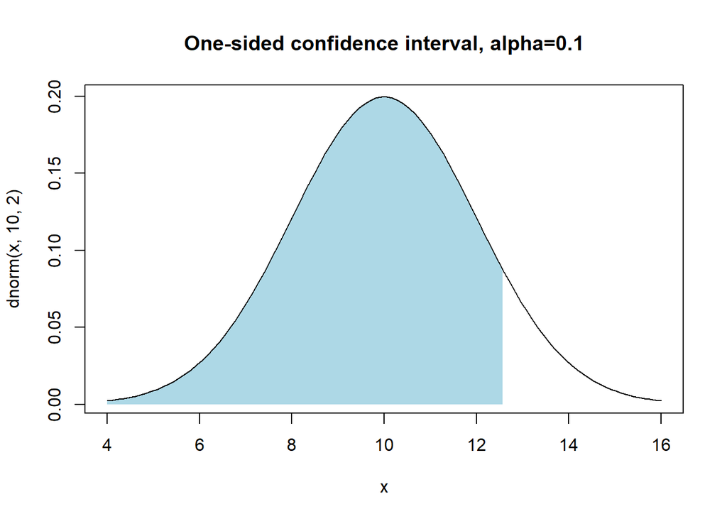

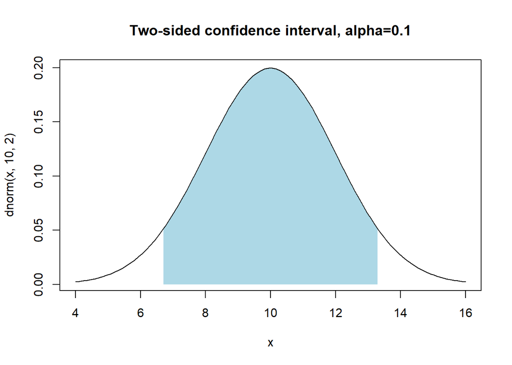

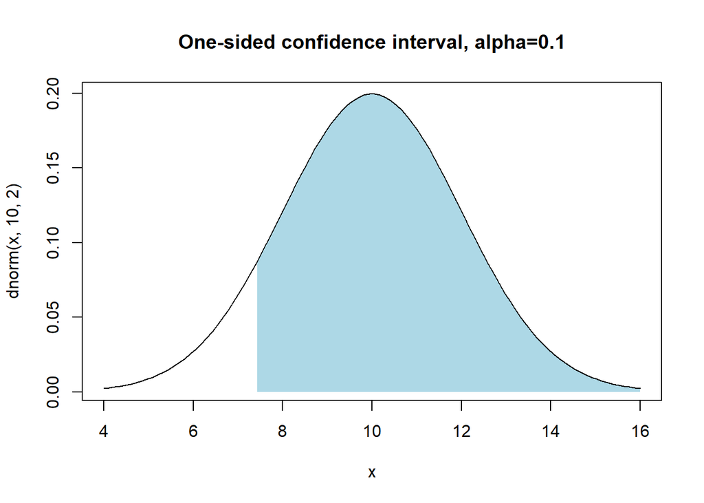

These intervals are constructed with the quantile functions. Recall that the quantile function $Q$ is the inverse c.d.f.

If I take the interval $(Q(0), Q(0.9))$, this gives exactly a (one-sided) 0.9-confidence interval. Likewise, the interval $(Q(0.05), Q(0.95))$ also gives a (two-sided) 0.9-confidence interval.

It is common to parameterise this confidence interval, usually with $\alpha$ as the significance level in hypothesis testing, thus forming $(1 - \alpha)$-confidence intervals, which are $(Q(0), Q(1-\alpha))$, $(Q(\alpha), Q(1))$, and $(Q(\alpha/2), Q(1-\alpha/2))$.

For example, if $\alpha = 0.05$, we get 0.95-confidence intervals.

These confidence intervals can be manually derived using a [z-table](https://math.arizona.edu/~rsims/ma464/standardnormaltable.pdf) (or t-table) if we standardise the distributions to have mean 0 and variance 1.

Continuing on with the example that our sample mean $\bar{X} \sim N(10, 4)$, we instead consider the standardised sample mean $((\bar{X}-10)/2) \sim N(0,1)$ since it is a well-known distribution with pre-computed quantiles. We get the quantiles of interest from the z-table - for a 90% confidence interval, say $\pm1.645$.

$$\begin{align*}
0.9 = P \left( -1.645 \leq \frac{\bar{X}-10}{2} \leq 1.645 \right)
&= P(-3.29 \leq \bar{X}-10 \leq 3.29) \\
&= P(6.71 \leq \bar{X} \leq 13.29)
= 0.9
\end{align*}$$

From which we can see a 0.9-confidence interval is $(6.71, 13.29)$, which lines up with the two-sided confidence interval graphed above.

# Confidence intervals for proportions

The confidence intervals for proportions may seem randomly defined but has an easy enough derivation, but requires some background knowledge.

## Bernoulli distribution

The Bernoulli distribution can only take on the values 0 or 1, and has pdf $f_X(x) = p^x(1-p)^{1-x}$ for $x \in \{0, 1\}$. It takes on value 1 with probability $p$ and 0 with probability $1-p$.

The expectation (mean) and variance can be easily calculated: $E(X) = p$ and $Var(X)=p(1-p)$.

So, suppose that we have $X_1, \dots, X_n$ representing polls of an audience - 1 and 0 representing the responses (whatever they may be). We model them as identically and independently distributed (i.i.d.) Bernoulli variables. The sample mean $\bar{X}$ thus represents the proportion of respondents to the poll who responded positively (recorded as 1).

Since $\bar{X} = \frac{1}{n}\sum_{i=1}^n X_i$, with big enough $n$, we apply the central limit theorem, so we say $\bar{X}$ is normally distributed. To find the parameters of the normal distribution, then we simply take our best guess of the mean - the sample mean of our data - and variance - calculated based on the data.

## Variance of the sample mean

Since $\bar{X} = \frac{1}{n}\sum_{i=1}^n X_i$, the variance on both sides is equal, i.e. $Var (\bar{X}) = Var(\frac{1}{n} \sum_{i=1}^n X_i) = \frac{1}{n^2} Var(\sum_{i=1}^n X_i)$.

Since all the $X_i$ are i.i.d., we have that $Var(\sum_{i=1}^n X_i) = \sum_{i=1}^n Var(X_i)$. We know $Var(X_i) = p(1-p)$, which holds for all $i = 1, \dots, n$, so $\sum_{i=1}^n Var(X_i) = \sum_{i=1}^n p(1-p) = np(1-p)$.

We can conclude that $Var(\bar{X}) = \frac{1}{n^2}np(1-p) = \frac{p(1-p)}{n}$, and therefore the standard deviation is $\sqrt{\frac{p(1-p)}{n}}$. After applying the central limit theorem, we thus have $\bar{X} \sim N(\mu, \frac{p(1-p)}{n})$ where $\mu$ is the sample mean of our observed data.

Once we have the distribution of $\bar{X}$, we can get the confidence intervals in the exact same manner: standardise it to $N(0,1)$ and we can use the z-scores!